# TD9 : Statistiques descriptives, intervalles de confiance et tests en Python

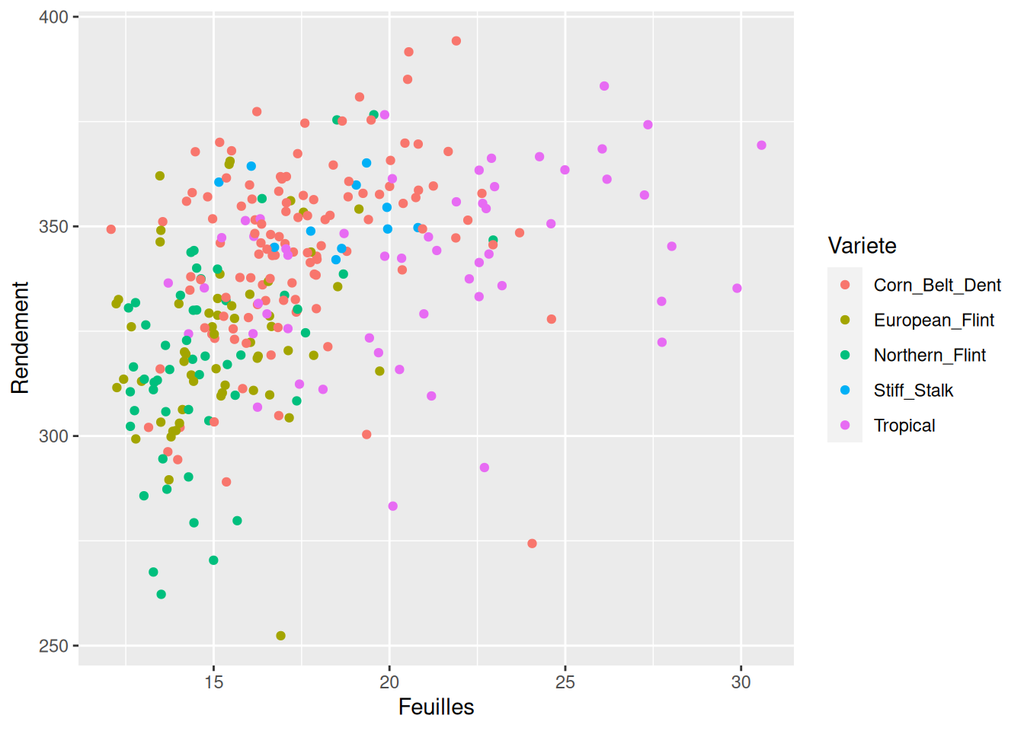

```r
ggplot(data,aes(x=Feuilles,y=Rendement,color=Variete)) + geom_point()
```

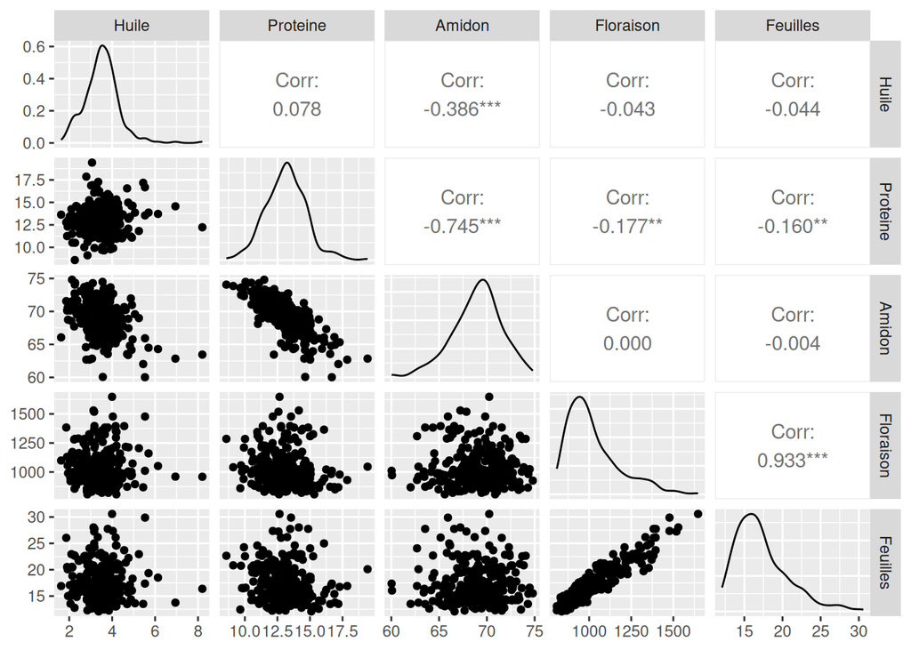

```r
ggpairs(data[,c("Huile","Proteine","Amidon","Floraison","Feuilles")])
```

Quelles variables ont une influence sur le rendement ?

## Exercice 1 : Étude du rendement pour la variété `Corn_Belt_Dent`

On suppose que le rendement pour la variété `Corn_Belt_Dent` suit une loi normale de moyenne $\mu$ et de variance $\sigma^2$.

On peut extraire ainsi les rendements obtenus avec la variété `Corn_Belt_Dent` :

```r
rendCBD = data$Rendement[data$Variete=="Corn_Belt_Dent"]
```

1. Calculer la moyenne totale des rendements et la moyenne des rendements pour la variété `Corn_Belt_Dent`.
2. Construire un intervalle de confiance de niveau de confiance 95$\%$ pour la moyenne $\mu$ des rendements pour la variété `Corn_Belt_Dent`.
3. Construire un intervalle de confiance de niveau de confiance 95$\%$ pour la variance $\sigma^2$ des rendements pour la variété `Corn_Belt_Dent`.
4. Construire un test pour répondre à la question : ” le rendement pour la variété `Corn_Belt_Dent` est-il supérieur à 336? ” au risque 5$\%$.

## Exercice 2 : Étude des marqueurs

On s’intéresse à la présence du marqueur 1 sur les maïs génotypés.

1. Calculer la proportion du marqueur 1 parmi tous les maïs.

```r
mean(data$Marqueur==1)
```

```
## [1] 0.3680556
```

2. Construire un intervalle de confiance de niveau de confiance 95$\%$ pour la proportion du marqueur 1 parmi tous les maïs.
3. Construire un test pour répondre à la question : ” la proportion du marqueur 1 parmi tous les maïs est-elle égale à 1/2 ” au risque 5%.

## Exercice 3 : Comparaison des rendements pour les variétés `Corn_Belt_Dent` et `European_Flint`

Construire un test au risque 5$\%$ de l’égalité des rendements pour les variétés `Corn_Belt_Dent` et `European_Flint`.

On peut extraire ainsi les rendements :

```r
rendCBD = data$Rendement[data$Variete=="Corn_Belt_Dent"]
rendEF = data$Rendement[data$Variete=="European_Flin"]
```